# Problem Set 3

Benjamin Söllner

September 2015

# 1- Diamonds

```r
library(ggplot2)
data(diamonds) # load data
summary(diamonds) # summary of variables
```

```
##      carat               cut        color        clarity
##  Min.   :0.2000   Fair     : 1610   D: 6775   SI1    :13065
##  1st Qu.:0.4000   Good     : 4906   E: 9797   VS2    :12258
##  Median :0.7000   Very Good:12082   F: 9542   SI2    : 9194
##  Mean   :0.7979   Premium  :13791   G:11292   VS1    : 8171
##  3rd Qu.:1.0400   Ideal    :21551   H: 8304   VVS2   : 5066
##  Max.   :5.0100                     I: 5422   VVS1   : 3655
##                                     J: 2808   (Other): 2531
##      depth           table           price             x
##  Min.   :43.00   Min.   :43.00   Min.   :  326   Min.   : 0.000
##  1st Qu.:61.00   1st Qu.:56.00   1st Qu.:  950   1st Qu.: 4.710
##  Median :61.80   Median :57.00   Median : 2401   Median : 5.700
##  Mean   :61.75   Mean   :57.46   Mean   : 3933   Mean   : 5.731
##  3rd Qu.:62.50   3rd Qu.:59.00   3rd Qu.: 5324   3rd Qu.: 6.540
##  Max.   :79.00   Max.   :95.00   Max.   :18823   Max.   :10.740
##
##        y                z
##  Min.   : 0.000   Min.   : 0.000
##  1st Qu.: 4.720   1st Qu.: 2.910
##  Median : 5.710   Median : 3.530
##  Mean   : 5.735   Mean   : 3.539
##  3rd Qu.: 6.540   3rd Qu.: 4.040
##  Max.   :58.900   Max.   :31.800
##
```

```r
dim(diamonds) # dimensions (observations times variables)
```

```
## [1] 53940    10
```

```r
nrow(diamonds) # number of observations
```

```
## [1] 53940
```

**How many observations are in the data set?**: 53940

**How many variables are in the data set?**: 10

**How many ordered factors are in the data set?**: 3

**What represents the best colour?**: D

# 2- Price Histogram

```
## stat_bin: binwidth defaulted to range/30. Use 'binwidth = x' to adjust this.
```

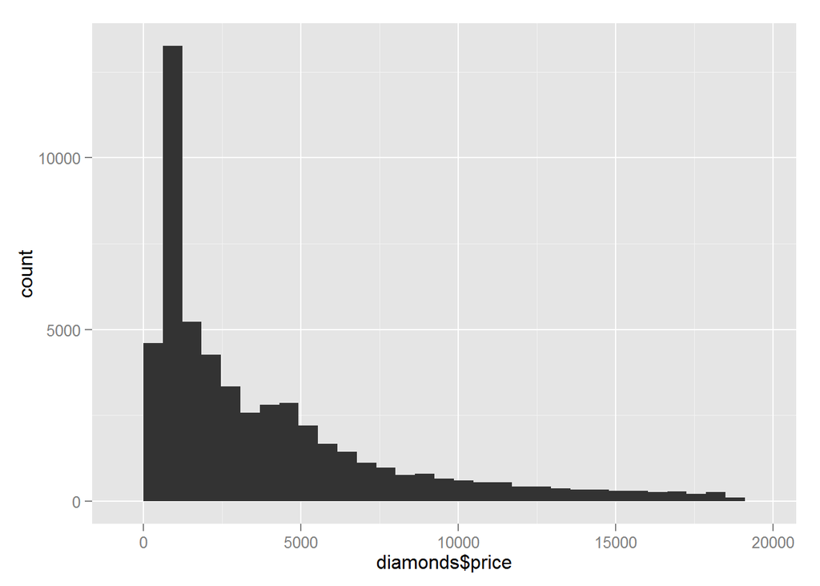

```r
qplot(diamonds$price)
```

# 3- Price Histogram Summary

```r
summary(diamonds$price)
```

```
##    Min. 1st Qu.  Median    Mean 3rd Qu.    Max.
##     326     950    2401    3933    5324   18820
```

- Min: 326
- 1st Qu.: 950
- 3rd Qu.: 5324
- Max: 18820

# 4- Diamond Counts

```r
nrow(subset(diamonds, price<500))
```

```
## [1] 1729
```

```r
nrow(subset(diamonds, price<250))
```

```
## [1] 0
```

```r
nrow(subset(diamonds, price>=15000))
```

```
## [1] 1656
```

**How many diamonds cost less than $500?**: 1729

**How many diamonds cost less than $250?**: 0

**How many diamonds cost $15,000 or more?**: 1656

# 5- Cheaper Diamonds

Exploring the median region:

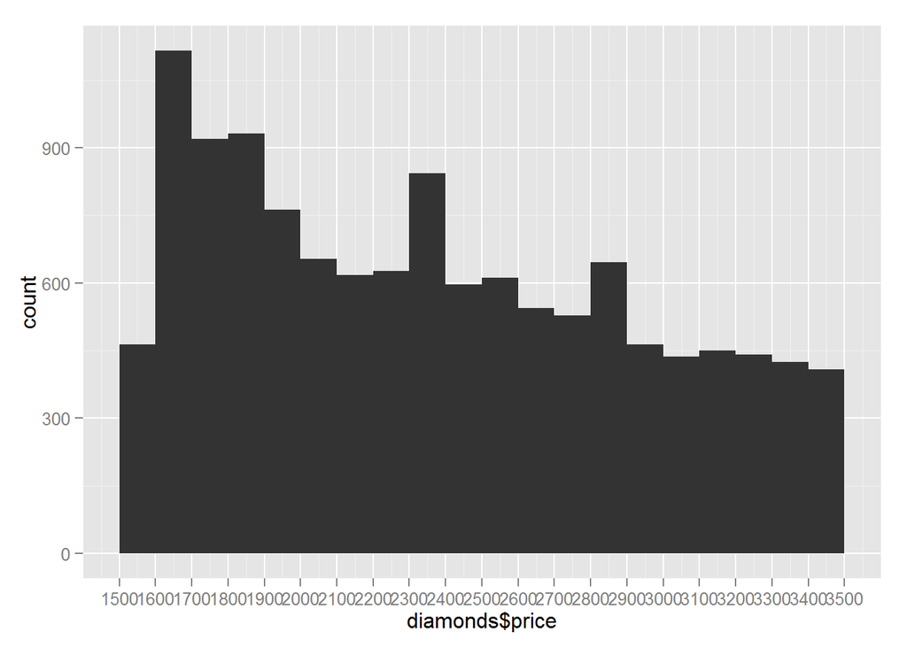

```r
qplot(diamonds$price, binwidth = 100) +
  scale_x_continuous(limits = c(1500, 3500),
                     breaks = seq(1500, 3500, 100))
```

There are no diamonds that cost $1500.

# 6- Price by Cut Histogram

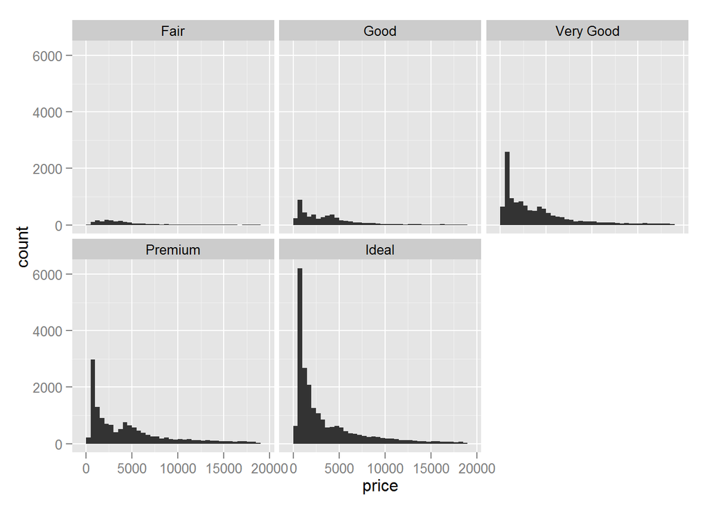

```r
qplot(x=price, data=diamonds, binwidth = 500) +
  facet_wrap(~cut,ncol=3)
```

Similar distributions.

# 7- Price by Cut

```r
by(diamonds$price, diamonds$cut, summary, digits = max(getOption('digits')))
```

```
## diamonds$cut: Fair
##      Min.   1st Qu.    Median      Mean   3rd Qu.      Max.
##   337.000  2050.250  3282.000  4358.758  5205.500 18574.000
## --------------------------------------------------------
## diamonds$cut: Good
##      Min.   1st Qu.    Median      Mean   3rd Qu.      Max.
##   327.000  1145.000  3050.500  3928.864  5028.000 18788.000
## --------------------------------------------------------
## diamonds$cut: Very Good
##     Min.  1st Qu.   Median     Mean  3rd Qu.     Max.
##   336.00   912.00  2648.00  3981.76  5372.75 18818.00
## --------------------------------------------------------
## diamonds$cut: Premium
##      Min.   1st Qu.    Median      Mean   3rd Qu.      Max.
##   326.000  1046.000  3185.000  4584.258  6296.000 18823.000
## --------------------------------------------------------
## diamonds$cut: Ideal
##      Min.   1st Qu.    Median      Mean   3rd Qu.      Max.
##   326.000   878.000  1810.000  3457.542  4678.500 18806.000
```

**Which cut has the highest priced diamond?:** Premium ($18823.00)

**Which cut has the lowest priced diamond?:** Premium & Ideal ($326.00)

**WHich cut has the lowest median price?:** Ideal ($1810.000)

# 8- Scales and Multiple Histograms

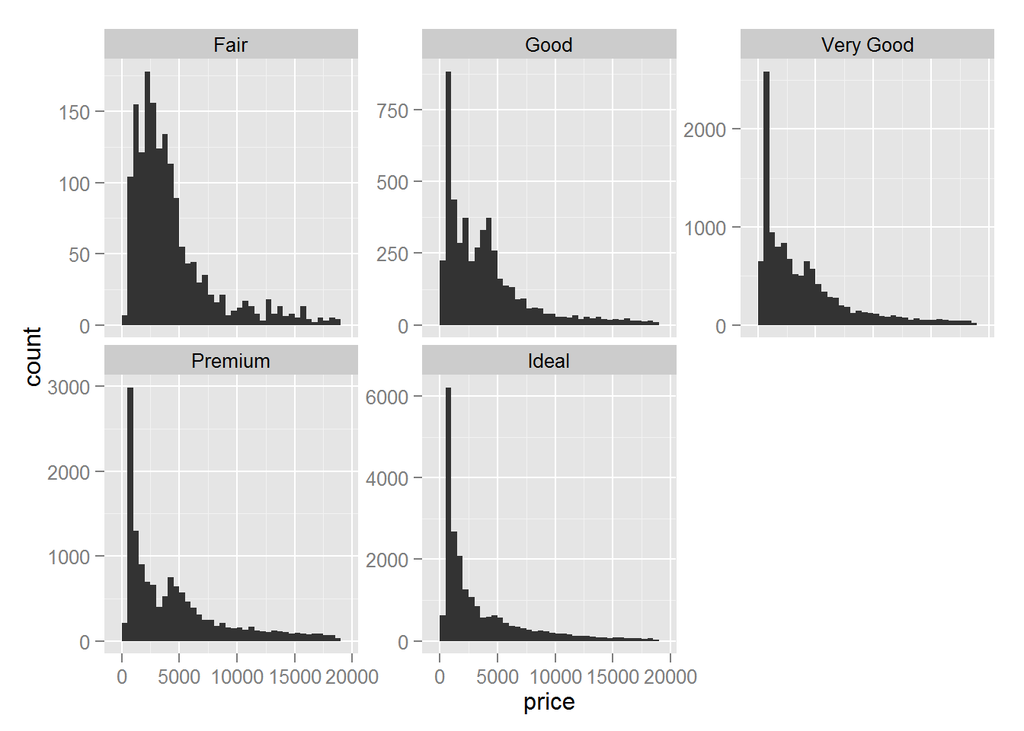

```r
qplot(x=price, data=diamonds, binwidth = 500) +
  facet_wrap(~cut,ncol=3,scales="free_y")
```

Shows the uniformity of distribution better by making the y-axis scale on demand.

# 9- Price per Carat by Cut

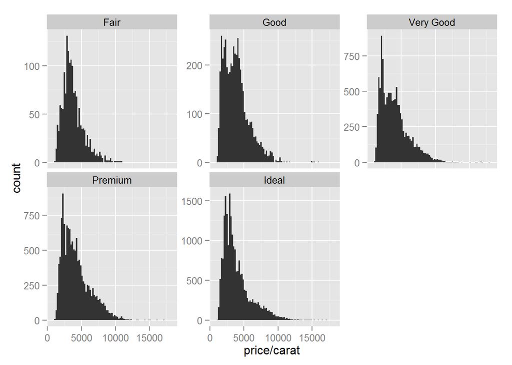

```r
qplot(x=price/carat, data=diamonds, binwidth=200) +
  facet_wrap(~cut,ncol=3,scales="free_y")
```

```
## stat_bin: binwidth defaulted to range/30. Use 'binwidth = x' to adjust this.
## stat_bin: binwidth defaulted to range/30. Use 'binwidth = x' to adjust this.
## stat_bin: binwidth defaulted to range/30. Use 'binwidth = x' to adjust this.
## stat_bin: binwidth defaulted to range/30. Use 'binwidth = x' to adjust this.
## stat_bin: binwidth defaulted to range/30. Use 'binwidth = x' to adjust this.
```

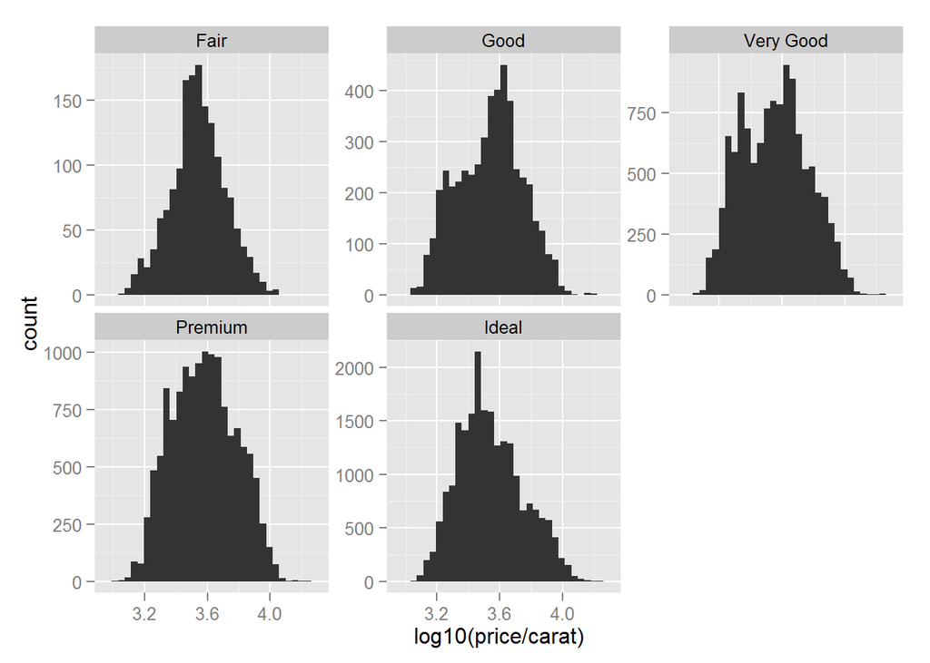

```r
qplot(x=log10(price/carat), data=diamonds) +
  facet_wrap(~cut,ncol=3,scales="free_y")
```

First showing skewed, second normalized distribution (using log transformation).

# 10- Price Box Plot

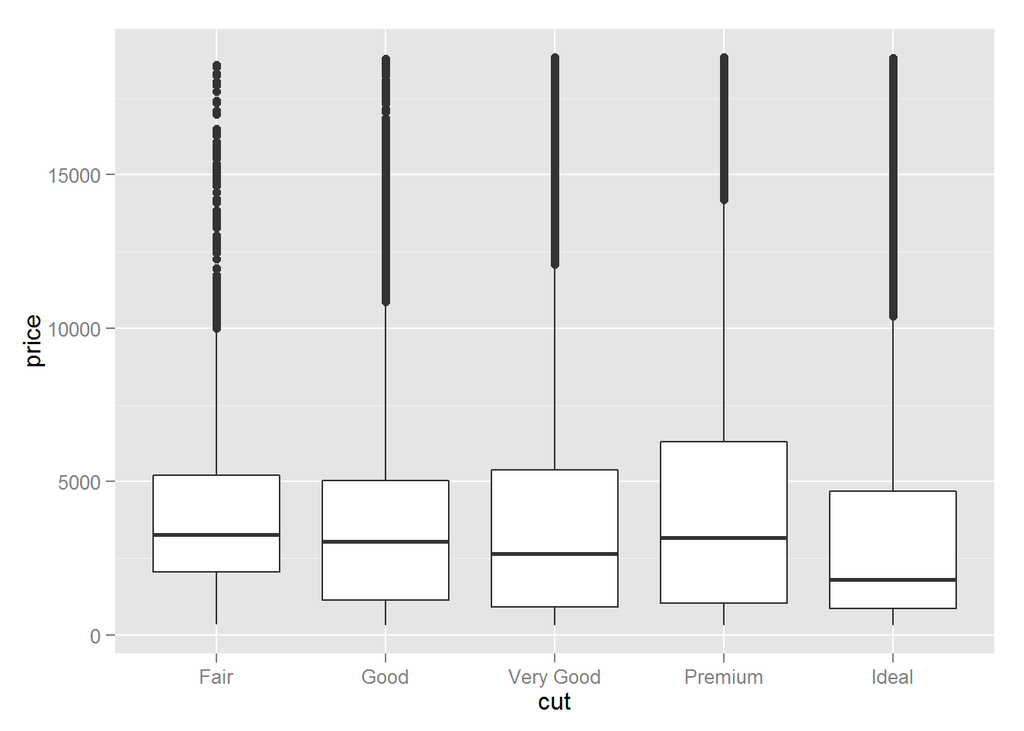

```r
qplot(y=price, x=cut, data=diamonds, geom='boxplot')
```

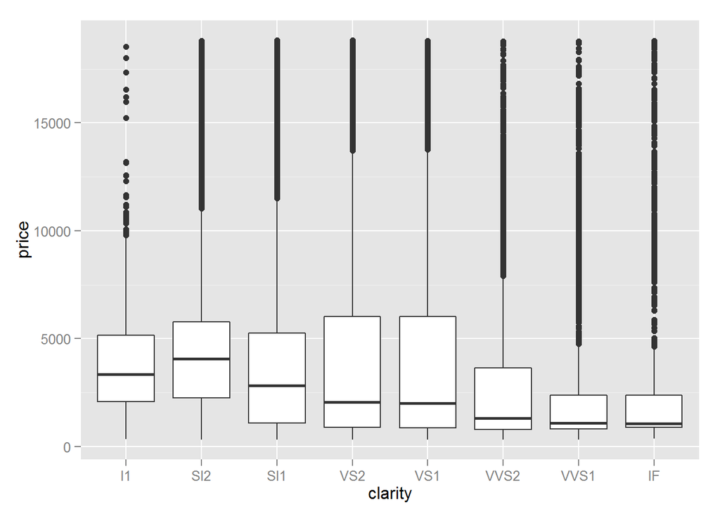

```r
qplot(y=price, x=clarity, data=diamonds, geom='boxplot')
```

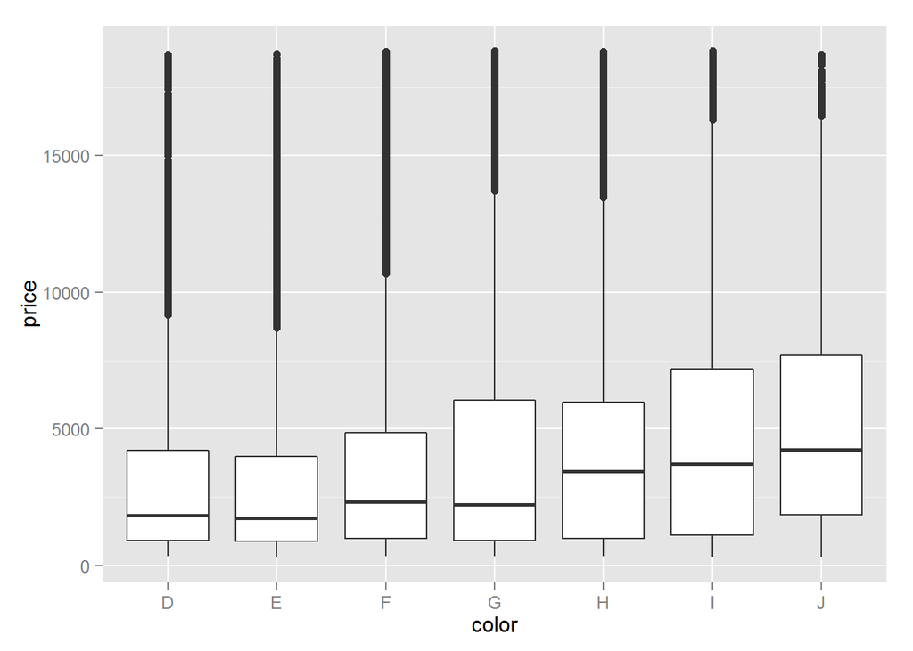

```r
qplot(y=price, x=color, data=diamonds, geom='boxplot')
```

```r
by(diamonds$price, diamonds$cut, summary)
```

```
## diamonds$cut: Fair
##    Min. 1st Qu.  Median    Mean 3rd Qu.    Max.
##     337    2050    3282    4359    5206   18570
## --------------------------------------------------------
## diamonds$cut: Good
##    Min. 1st Qu.  Median    Mean 3rd Qu.    Max.
##     327    1145    3050    3929    5028   18790
## --------------------------------------------------------
## diamonds$cut: Very Good
##    Min. 1st Qu.  Median    Mean 3rd Qu.    Max.
##     336     912    2648    3982    5373   18820
## --------------------------------------------------------
## diamonds$cut: Premium
##    Min. 1st Qu.  Median    Mean 3rd Qu.    Max.
##     326    1046    3185    4584    6296   18820
## --------------------------------------------------------
## diamonds$cut: Ideal
##    Min. 1st Qu.  Median    Mean 3rd Qu.    Max.
##     326     878    1810    3458    4678   18810
```

```r
by(diamonds$price, diamonds$clarity, summary)
```

```
## diamonds$clarity: I1
##    Min. 1st Qu.  Median    Mean 3rd Qu.    Max.
##     345    2080    3344    3924    5161   18530
## --------------------------------------------------------
## diamonds$clarity: SI2
##    Min. 1st Qu.  Median    Mean 3rd Qu.    Max.
##     326    2264    4072    5063    5777   18800
## --------------------------------------------------------
## diamonds$clarity: SI1
##    Min. 1st Qu.  Median    Mean 3rd Qu.    Max.
##     326    1089    2822    3996    5250   18820
## --------------------------------------------------------
## diamonds$clarity: VS2
##    Min. 1st Qu.  Median    Mean 3rd Qu.    Max.
##     334     900    2054    3925    6024   18820
## --------------------------------------------------------
## diamonds$clarity: VS1
##    Min. 1st Qu.  Median    Mean 3rd Qu.    Max.
##     327     876    2005    3839    6023   18800
## --------------------------------------------------------
## diamonds$clarity: VVS2
##    Min. 1st Qu.  Median    Mean 3rd Qu.    Max.
##   336.0   794.2  1311.0  3284.0  3638.0 18770.0
## --------------------------------------------------------
## diamonds$clarity: VVS1
##    Min. 1st Qu.  Median    Mean 3rd Qu.    Max.
##     336     816    1093    2523    2379   18780
## --------------------------------------------------------
## diamonds$clarity: IF
##    Min. 1st Qu.  Median    Mean 3rd Qu.    Max.
##     369     895    1080    2865    2388   18810
```

```r
by(diamonds$price, diamonds$color, summary)
```

```
## diamonds$color: D
##    Min. 1st Qu.  Median    Mean 3rd Qu.    Max.
##     357     911    1838    3170    4214   18690
## --------------------------------------------------------
## diamonds$color: E
##    Min. 1st Qu.  Median    Mean 3rd Qu.    Max.
##     326     882    1739    3077    4003   18730
## --------------------------------------------------------
## diamonds$color: F
##    Min. 1st Qu.  Median    Mean 3rd Qu.    Max.
##     342     982    2344    3725    4868   18790
## --------------------------------------------------------
## diamonds$color: G
##    Min. 1st Qu.  Median    Mean 3rd Qu.    Max.
##     354     931    2242    3999    6048   18820
## --------------------------------------------------------
## diamonds$color: H
##    Min. 1st Qu.  Median    Mean 3rd Qu.    Max.
##     337     984    3460    4487    5980   18800
## --------------------------------------------------------
## diamonds$color: I
##    Min. 1st Qu.  Median    Mean 3rd Qu.    Max.
##     334    1120    3730    5092    7202   18820
## --------------------------------------------------------
## diamonds$color: J
##    Min. 1st Qu.  Median    Mean 3rd Qu.    Max.
##     335    1860    4234    5324    7695   18710
```

# 11- Interquartile Range - IQR

```r
quantile(subset(diamonds, color=="D")$price)
```

```
##      0%     25%     50%     75%    100%
##   357.0   911.0  1838.0  4213.5 18693.0
```

```r
quantile(subset(diamonds, color=="J")$price)
```

```
##      0%     25%     50%     75%    100%
##   335.0  1860.5  4234.0  7695.0 18710.0
```

```r
IQR(subset(diamonds, color=="D")$price)
```

```
## [1] 3302.5
```

```r
IQR(subset(diamonds, color=="J")$price)
```

```
## [1] 5834.5
```

**Quartiles for color D**: first: $911.0, third: $4213.5

# 12- Price per Carat Box Plots by Color

Price per carat of diamonds across the different colors of diamonds using boxplots:

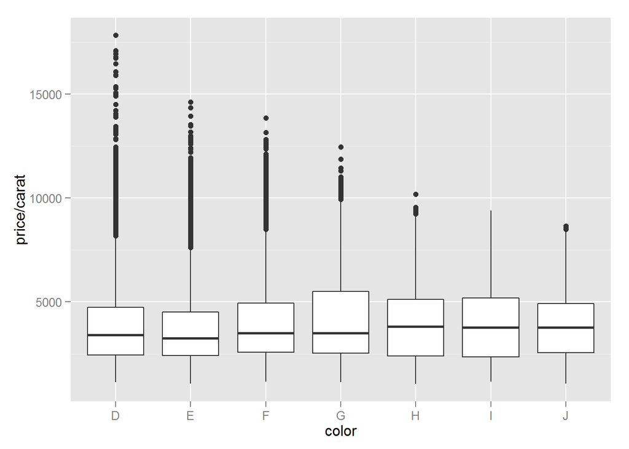

```r
qplot(y=price/carat, x=color, data=diamonds, geom='boxplot')
```

# 12- Carat Frequency Polygon

Investigating the weight of the diamonds (carat) using a frequency polygon.

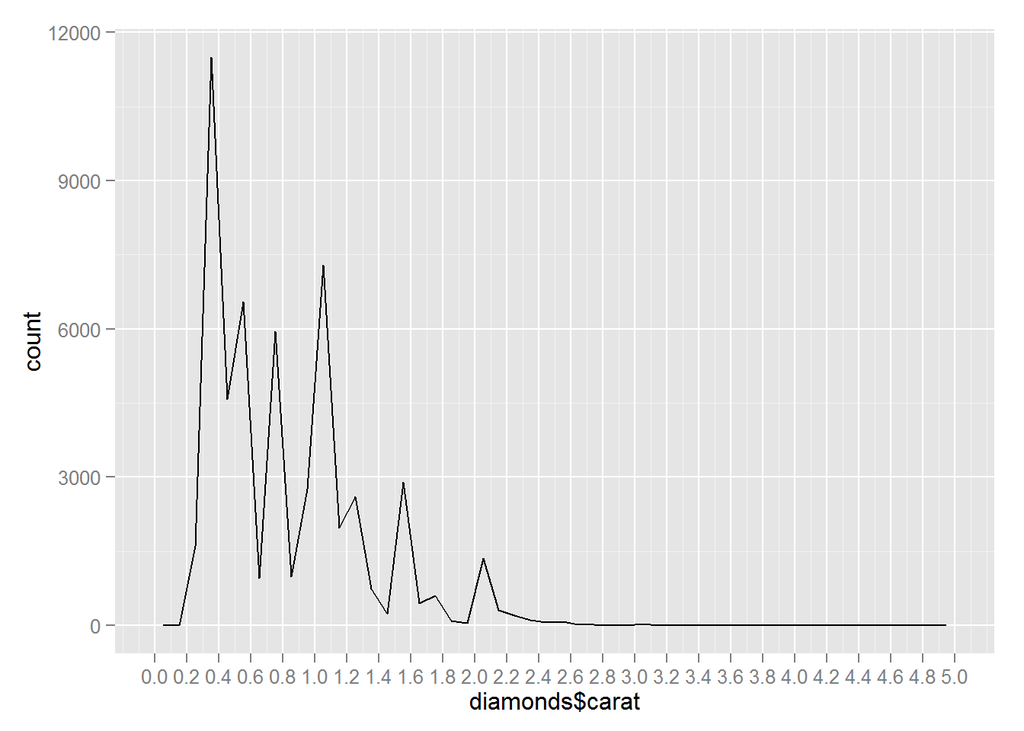

```r
qplot(diamonds$carat, binwidth=0.1, geom='freqpoly') +
  scale_x_continuous(limits = c(0, 5),
                     breaks = seq(0, 5, 0.2))
```

# 13- Data Wrangling With R

Useful Links:

- [Data Wrangling in R Intro](https://s3.amazonaws.com/udacity-hosted-downloads/ud651/DataWranglingWithR.pdf)
- [Data Wrangling in R Cheat Sheet](http://www.rstudio.com/wp-content/uploads/2015/02/data-wrangling-cheatsheet.pdf)
- [Other RStudio Cheat Sheets](http://www.rstudio.com/resources/cheatsheets/)

```r
# install.packages("tidyr")
# install.packages("dplyr")
```

# 14- Gapminder Data

Analyzing countries by gender about global health: let’s see how the global health of different genders is doing in different countries over the years.

```r
library(tidyr)
library(dplyr)
```

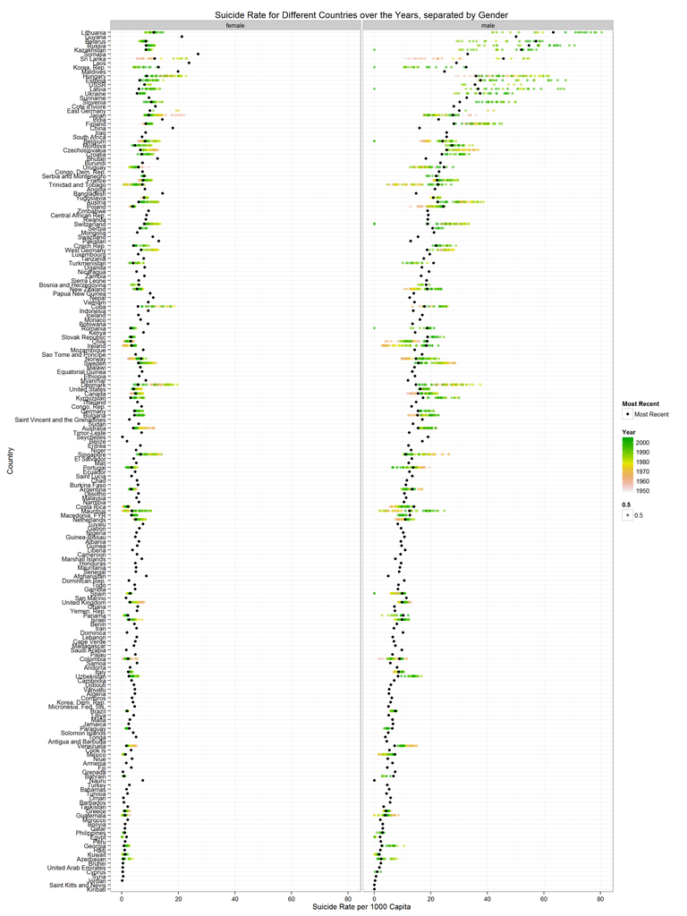

```r
library(ggplot2)

# read data
setwd('h:/Dokumente/GitHub/2015_Data_Analyst_Project_4/lesson3/')
f <- read.csv('Suicide female indicator file UL 20100916.csv', header=T, check.names=F)
m <- read.csv('Suicide male indicator file UL 20100916.csv', header=T, check.names=F)

# rename first column to "country"
colnames(f)[1] <- "country"
colnames(m)[1] <- "country"

# gather year rows into key-value pairs for columns "year" and "fraction"
f.gathered <- tidyr::gather(f, "year", "fraction", 2:length(f))
m.gathered <- tidyr::gather(m, "year", "fraction", 2:length(m))

# add a "gender" column
f.mutated <- dplyr::mutate(f.gathered, gender = "female")
m.mutated <- dplyr::mutate(m.gathered, gender = "male")

# throw data in same pot
data.untidy <- dplyr::bind_rows(f.mutated, m.mutated)

# final cleaning (re-ordering columns, filtering out NAs)
data.tidy <- dplyr::filter(data.untidy[,c(1,2,4,3)], !is.na(fraction))

# Convert year to numeric
data.tidy$year = as.numeric(levels(data.tidy$year))[data.tidy$year]

# Compute most recent years stats
data.now <- dplyr::summarise(dplyr::group_by(data.tidy, country, gender), nowyear=max(year)) %>%
  dplyr::left_join(data.tidy, c("nowyear" = "year", "country" = "country", "gender" = "gender")) %>%
  dplyr::rename(nowfraction=fraction)
# Add summary stats to table
data.tidy <- dplyr::left_join(data.tidy, data.now, c("country" = "country", "gender" = "gender"))


# Graph

# Graph "fraction"" as y and "country" re-ordered by mean.fraction as x
ggplot(data = data.tidy, aes(x=reorder(country, nowfraction), y=fraction)) +
  # Yearly data should appear as a color-coded data point (we are using a reversed terrain colour palette)
  geom_point(aes(colour=year, alpha=0.5)) +
  scale_colour_gradientn(colours=rev(terrain.colors(length(f)-1)), name="Year") +
  # We also will plot the mean as a circle
  geom_point(aes(y=nowfraction, shape="O")) +
  scale_shape_discrete(name="Most Recent", labels=c("Most Recent")) +
  # Facet wrap by gender
  facet_wrap(~gender, ncol=2) +
  # Themes, Labels, Titles
  coord_flip() +
  theme_bw() +
  #theme(axis.text.x = element_text(angle = 90, hjust = 1)) +
  xlab("Country") +
  ylab("Suicide Rate per 1000 Capita") +
  ggtitle("Suicide Rate for Different Countries over the Years, separated by Gender")
```

# 15- Analyzing Friends Birthdays

Analyzing distribution of my friend’s birthdays

```r
setwd('h:/Dokumente/GitHub/2015_Data_Analyst_Project_4/lesson3/')
# Loading data
birthdays <- read.csv('friends_birthdays.nogithub.csv', header=T, check.names=F)
# Renaming Columns
colnames(birthdays)[1] <- "Name"
colnames(birthdays)[2] <- "Date"
# Selecting relevant columns
birthdays <- dplyr::select(birthdays, Name, Date)
# Converting to Date
birthdays$Date <- as.Date(birthdays$Date, format="%d.%m.%Y")
# Cleaning: Replacing " birthday" / " Geburtstag" in Label (redundant)
dplyr::transmute(birthdays, Name=gsub(" Geburtstag", "", Name))
# Month and day
birthdays$Month <- as.factor(format(birthdays$Date, "%m"))
birthdays$Day   <- as.factor(format(birthdays$Date, "%d"))
```

## How many people share your birthday? Do you know them?

```r
subset(birthdays, Day=="02" & Month=="11")
```

```
##                             Name       Date Month Day
## 443 Benjamin Söllners Geburtstag 2016-11-02    11  02
## 444     Julia Walters Geburtstag 2016-11-02    11  02
```

Yes, one is me, the other one I know too.

## How many birthdays are in each month?

```r
birthday.months <- dplyr::summarise(dplyr::group_by(birthdays, Month), Count=length(Month))
```

## Which month contains the most number of birthdays?

```r
dplyr::arrange(birthday.months, desc(Count))
```

```
## Source: local data frame [12 x 2]
##
##     Month Count
##    (fctr) (int)
## 1      08    54
## 2      04    49
## 3      09    48
## 4      01    47
## 5      06    47
## 6      03    44
## 7      05    43
## 8      07    42
## 9      11    42
## 10     12    40
## 11     02    34
## 12     10    33
```

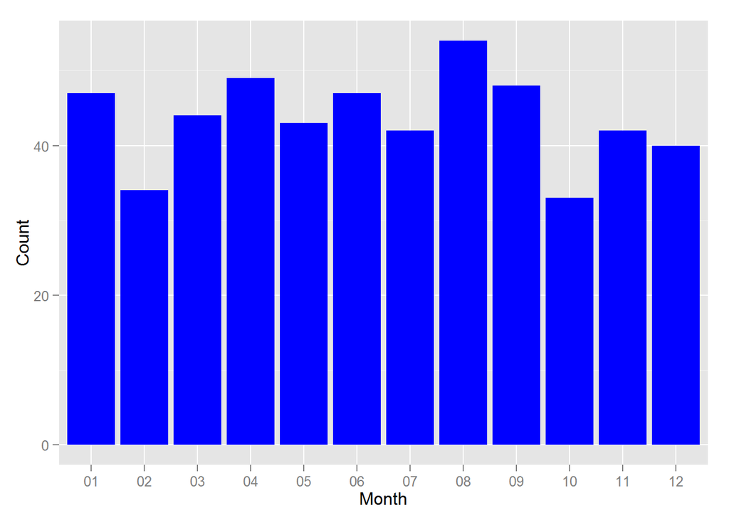

```r
qplot(data=birthday.months, x=Month, y=Count, geom="bar", stat="identity", fill=I('blue'))
```

August has the most number of birthdays.